# Exploratory Analysis of the Jobs Portfolio Data

## 0.1 Data Pre-processing

The data pre-processing steps are as follows

1. Remove all the unneccasary columns
2. Filter out the projects that are either active or in the pipeline.
3. Gather the data into a long format that represents the job types as a column
4. Join in the intervention types (macro meso etc) and the job types (more, better etc)
5. Change variable names

```r
projectData <- read_csv("raw data/jobsData.csv") %>%
        select(Proj.ID, 4, Proj.Type, Proj.FY, Proj.Region, Proj.Country, 10, Proj.Product_Line, Proj.Status, 227:243)
notClosed <- sum(projectData$Proj.Status != "Closed")
missingData <- nrow(projectData[projectData$Proj.Status != "Closed" & is.na(projectData$Intervention), ])
projectData <- projectData %>%
        filter(Proj.Status != "Closed" & !is.na(Intervention)) %>%
        gather(key = jobsName, value = value, 11:26) %>%
        left_join(., read_csv("raw data/interventionTypes.csv"), by = c("Intervention")) %>%
        left_join(., read_csv("raw data/jobTypes.csv"), by = c("jobsName"))
## Change var names
names(projectData) <- c("id", "gP", "projType", "fY", "region", "country", "countryType", "productLine", "status", "intervention", "jobsName", "value", "interventionType", "jobsType")
```

## 0.2 Some data issues

1. **Incomplete data:** The total number of active and pipeline projects is **1375** out of these **376** are missing the intervention type data (i.e. macro, meso etc). The total number of projects with information that we can visualize is **999**.
2. **Country variable contains regions:** The country variable in the dataset contains projects that are marked as Africa, Central America etc, instead of the names of the country.
3. **Skew** towards certain regions, job and intervention types.

## 0.3 Projects by Year

As expected there are more projects that are active or in the pipeline that are more recent.

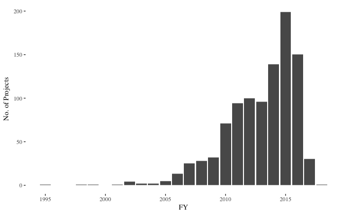

```r
projectData %>%
        group_by(fY) %>%
        summarise(nProject = n_distinct(id)) %>%
        ggplot(aes(x = fY, y = nProject)) +
        geom_bar(stat = "identity") +
        labs(x = "FY", y = "No. of Projects") +
        theme_tufte()
```

## 0.4 Projects by region

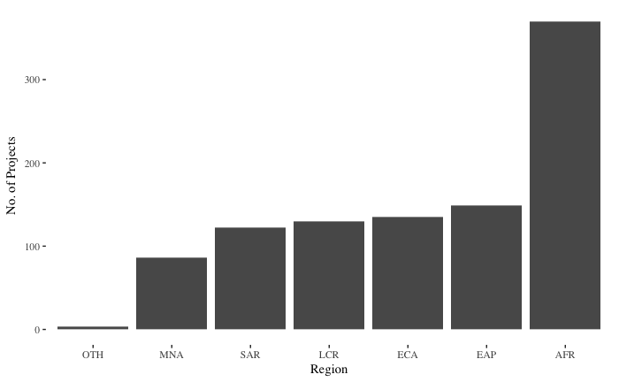

```r
projectData %>%
        group_by(region) %>%
        summarise(nProject = n_distinct(id)) %>%
        ggplot(aes(x = reorder(region, nProject), y = nProject)) +
        geom_bar(stat = "identity") +
        labs(x = "Region", y = "No. of Projects") +
        theme_tufte()
```

## 0.5 Project by GP

There is a skew towards certain GPs in the data.

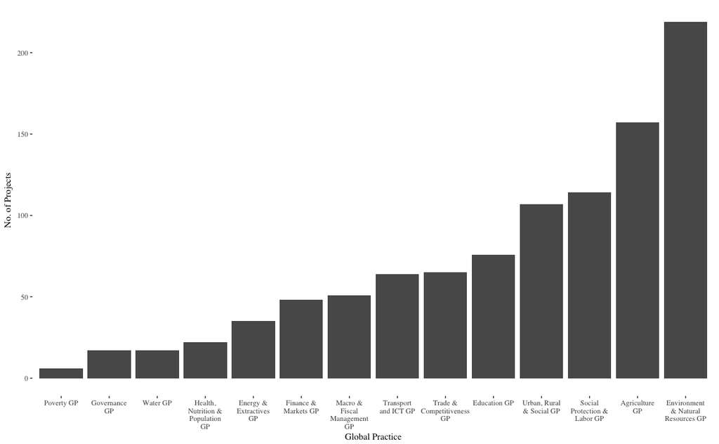

```r
projectData %>%
        group_by(gP) %>%
        summarise(nProject = n_distinct(id)) %>%
        ggplot(aes(x = reorder(gP, nProject), y = nProject)) +
        geom_bar(stat = "identity") +
        scale_x_discrete(label = function(x) str_wrap(x, width = 12)) +
        labs(x = "Global Practice", y = "No. of Projects") +
        theme_tufte()
```

## 0.6 Countries with more than 15 projects

We only have a few countries that have more than 15 projects. This counld be an issue if we are planning on doing cross country comparisons.

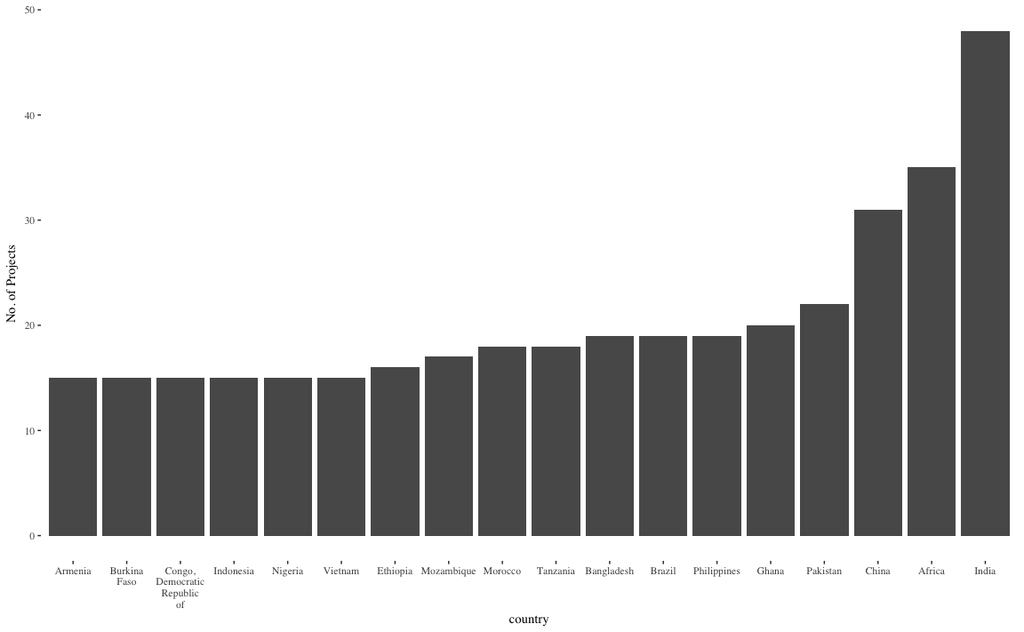

```r
projectData %>%
        group_by(country) %>%
        summarise(nProject = n_distinct(id)) %>%
        filter(nProject >= 15) %>%
        ggplot(aes(x = reorder(country, nProject), y = nProject)) +
        geom_bar(stat = "identity") +
        scale_x_discrete(label = function(x) str_wrap(x, width = 10)) +
        labs(x = "country", y = "No. of Projects") +
        theme_tufte()
```

## 0.7 Projects by intervention types

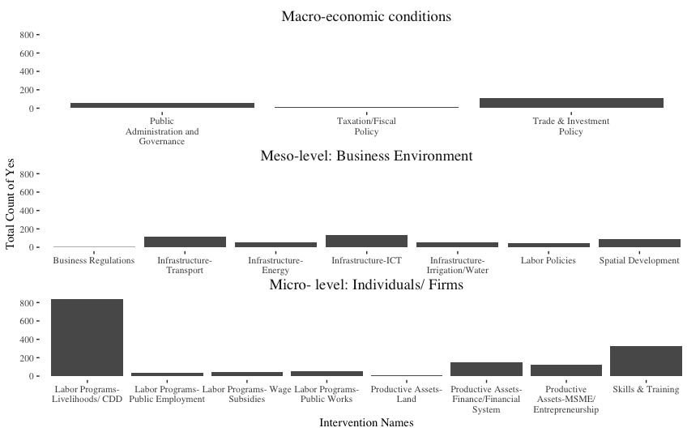

```r
projectData %>%
        group_by(intervention) %>%
        summarise(interventionType = unique(interventionType), interventionValue = sum(value == "Yes", na.rm = T)) %>%
        mutate(interventionType = factor(interventionType, levels = c("Macro-economic conditions", "Meso-level: Business Environment", "Micro- level: Individuals/ Firms"))) %>%
        ggplot(aes(x = intervention, y = interventionValue)) +
        geom_bar(stat = "identity") +
        facet_wrap(~ interventionType, strip.position = "top", scales = "free_x", ncol = 1) +
        scale_x_discrete(label = function(x) str_wrap(x, width = 20)) +
        labs(x = "Intervention Names", y = "Total Count of Yes") +
        theme_tufte() +
        theme(panel.spacing = unit(0, "lines"), strip.background = element_blank(), strip.placement = "outside",strip.text.x = element_text(size = 14))
```

## 0.8 Projects by job types

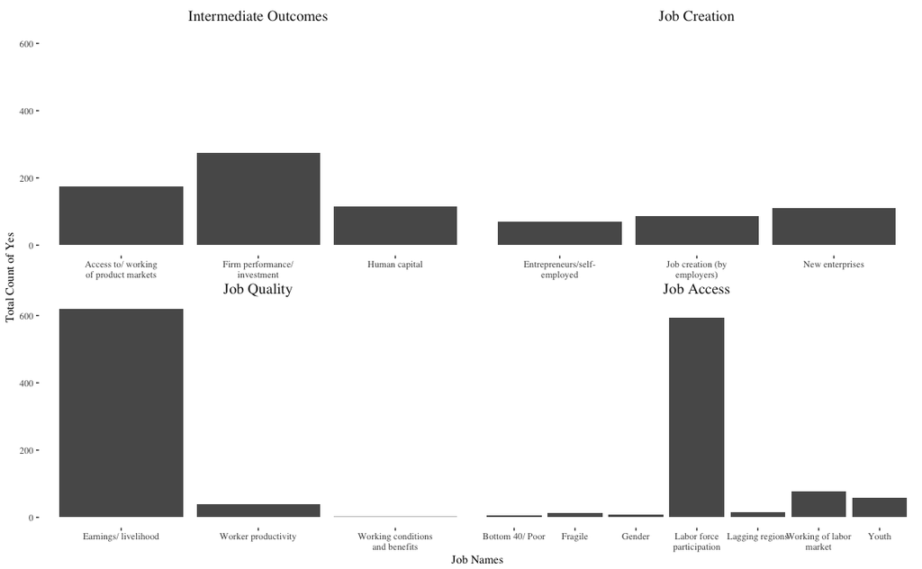

```r
projectData %>%
        group_by(jobsName) %>%
        summarise(jobsType = unique(jobsType), jobValue = sum(value == "Yes", na.rm = T)) %>%
        mutate(jobsType = factor(jobsType, levels = c("Intermediate Outcomes", "Job Creation", "Job Quality", "Job Access"))) %>%
        ggplot(aes(x = jobsName, y = jobValue)) +
        geom_bar(stat = "identity") +
        facet_wrap(~ jobsType, strip.position = "top", scales = "free_x") +
        scale_x_discrete(label = function(x) str_wrap(x, width = 20)) +
        labs(x = "Job Names", y = "Total Count of Yes") +
        theme_tufte() +
        theme(panel.spacing = unit(0, "lines"), strip.background = element_blank(), strip.placement = "outside", strip.text.x = element_text(size = 14))
```

## 0.9 Basic heatmaps of the current data

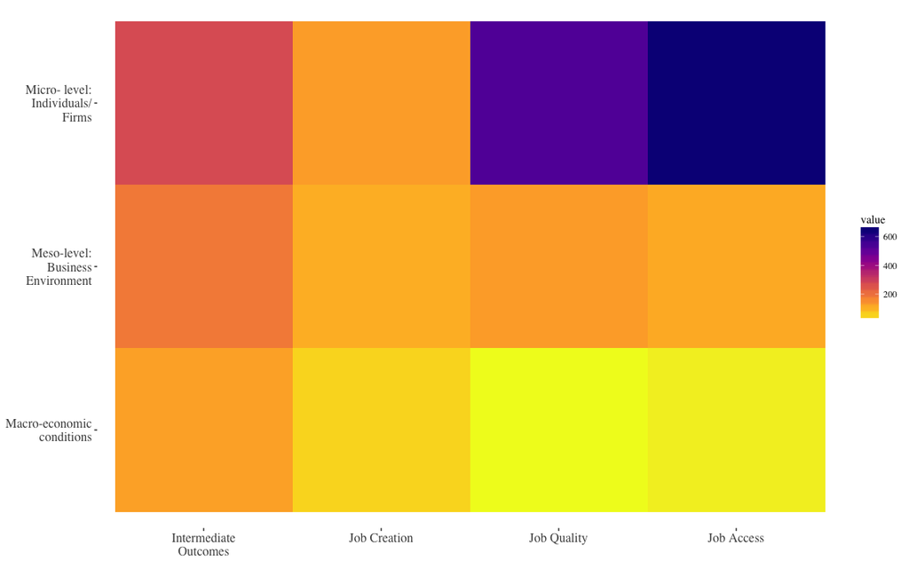

```r
projectData %>%
        mutate(interventionType = factor(interventionType, levels = c("Macro-economic conditions", "Meso-level: Business Environment", "Micro- level: Individuals/ Firms"), ordered = T), jobsType = factor(jobsType, levels = c("Intermediate Outcomes", "Job Creation", "Job Quality", "Job Access"))) %>%
        group_by(interventionType, jobsType) %>%
        summarise(value = sum(value == "Yes", na.rm = T)) %>%
        arrange(interventionType, jobsType) %>%
        ggplot(aes(x = jobsType, y = interventionType)) +
        geom_tile(aes(fill = value), linetype = 3) +
        scale_x_discrete(label = function(x) str_wrap(x, width = 12)) +
        scale_y_discrete(label = function(x) str_wrap(x, width = 15)) +
        scale_fill_viridis(option = "plasma", alpha = 0.5, direction = -1) +
        theme_tufte() +
        theme(axis.text = element_text(size = 12), axis.title = element_blank())
```

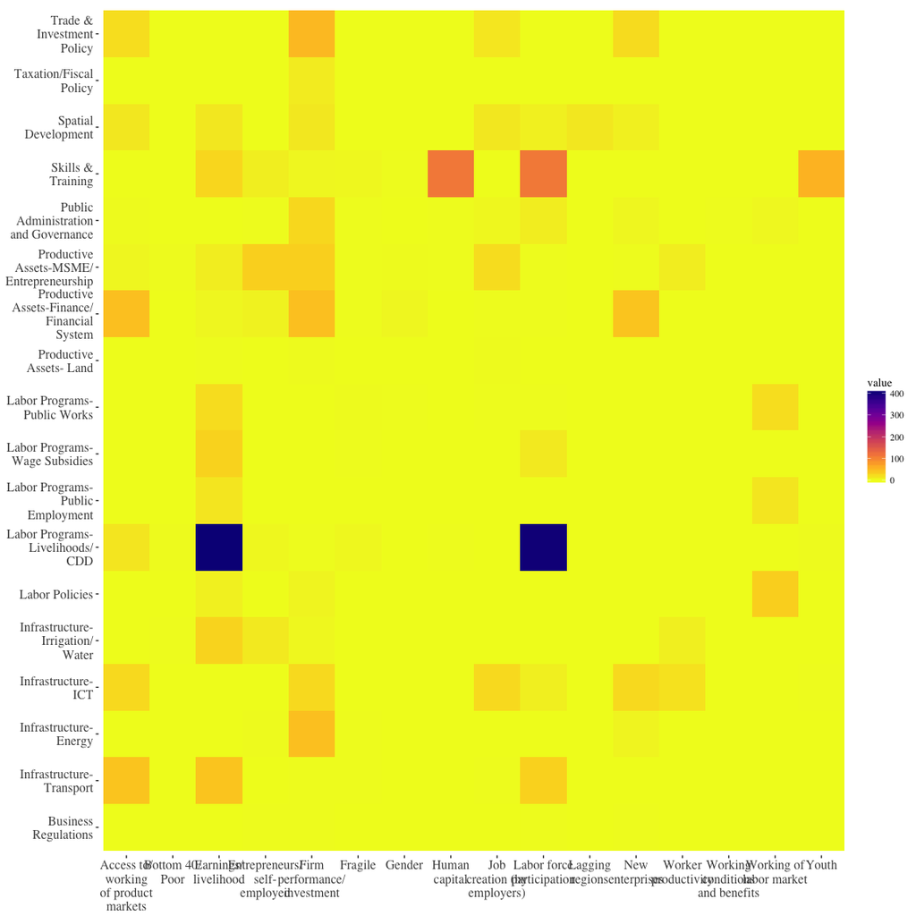

```r
projectData %>%
        group_by(intervention, jobsName) %>%
        summarise(interventionType = unique(interventionType), jobsType = unique(jobsType), value = sum(value == "Yes", na.rm = T)) %>%
        mutate(interventionType = factor(interventionType, levels = c("Macro-economic conditions", "Meso-level: Business Environment", "Micro- level: Individuals/ Firms"), ordered = T), jobsType = factor(jobsType, levels = c("Intermediate Outcomes", "Job Creation", "Job Quality", "Job Access"))) %>%
        arrange(interventionType, jobsType) %>%
        ggplot(aes(x = jobsName, y = intervention)) +
        geom_tile(aes(fill = value), linetype = 3) +
        scale_x_discrete(label = function(x) str_wrap(x, width = 12)) +
        scale_y_discrete(label = function(x) str_wrap(x, width = 15)) +
        scale_fill_viridis(option = "plasma", alpha = 0.5, direction = -1) +
        theme_tufte() +
        theme(axis.title = element_blank(), axis.text = element_text(size = 12))
```